# Demo 3: Bioinformatics of Gene Expression

Merrimack College DSE6630: Healthcare & Life Sciences Analytics

Team Sigma: Alourdes Joseph, June Lemieux, Melissa Nooney

2025-07-05

# 1 Introduction

You have just been hired by a university to work on a team with other biological data scientists working on responses of organisms to climate change. Native pollinators are of special importance because of agriculture and food security; but some pollinators are likely to experience thermal intolerance, especially to changes in temperatures that alter their core physiology because of rapid temperature changes.

Exposing bees and other insects to extreme cold puts them into what is often referred to as a **chill coma**: their body functions slow to the point that they go into torpor, which means they cannot move. Their physiology slows to the point that they are unable to move their flight muscles, for example. Here, we have differential gene expression data from the North American bumblebee, *Bombus impatiens*, which is both a native pollinator found throughout most of the U.S and Canada. It is also an important agricultural species because of its pollination services! Chill coma is essential to the survival of *B. impatiens* maiden queens as they overwinter; they need to emerge from their burrows in the ground in the spring to start their nests, lay eggs, rear larvae, and ultimately pollinate our food plants. Thus, understanding the genes underlying the species’ physiological responses to shifts in cold temperature, especially in light of predicted temperature shifts in North America, could be particularly important.

You were asked to work with other climate data scientists to re-analyze these chill coma experiment expression data using machine learning methods. Your goal is to perform a **benchmarking study** to see how your results compare to conventional methods. You will start with conventional methods and then apply machine learning methods after that to draw your comparisons.

**These data have never been explored this way before**. You can find the original paper here by Verble et al. (2023). Not only are you contributing to what we understand about best practices for gene expression analysis but you are doing **novel research** too! The original results by Verble et al. (2023) were very compelling, but these data are a perfect opportunity to do some benchmarking! You will see why…

## 1.1 Study Overview

According to the study, *Bombus impatiens* colonies were reared indoors for 72 hours and then treated individuals put into chill coma (Verble et al., 2023) by exposing them to $\approx$ 0$^{\circ}$ C (32$^{\circ} F$ for 75 min. Individuals were then killed at the following intervals to isolate their RNA (and thus measure gene expression at those number of minutes post-coma): 0 min, 10 min, 30 min, 120 min, and 720 min. Bumblebees (cold-treated and control from the same colony) were sacrificed by flash freezing them at -80 to await RNA isolation. This is because RNA is very unstable at room temperature, thus instantaneous death is essential to stop gene expression changes that might be happening in the organism. Overall, you have been given information about the bumblebee’s natal colony, whether the sample was put into a chill coma vs. control, as well as the duration of chill coma.

## 1.2 Sample Metadata

**Metadata** refer to information about sequencing files that describe the samples. This can include information about how the samples were collected, the **phenotypes** of the samples (the traits, physical or behavioral, that are thought to be at least partially controlled by gene expression diversity), and IDs for individuals or, in this case, colonies from which the data come.

Table 1. Metadata of the gene expression samples.

| Variable | Description |
| --- | --- |
| sampleID | The original ID of the sequencing sample obtained |
| Colony | The bumblebee colony from which the indiduals sampled came |
| Treatment | Control vs. Chill Exposure |
| Time | Duration of the treatment |

```
##   sampleID Colony Treatment Time
## 1  C00ECK5  daisy   Control  00m
## 2  C00ECK6  daisy   Control  00m
## 3 C00ECK40 dahlia   Control  00m
## 4 C00ECK77 violet   Control  00m
## 5  C10ECK7  daisy   Control  10m
## 6  C10ECK8  daisy   Control  10m
```

#### **Question 1**: [1 point]

Looking at the original study, what method of RNA sequencing was performed? This is an unusual method of sequencing, and you will need to look it up. Can you explain, approximately, how it works? (Give your best attempt)

> MN: From the article in the methods section, the authors chose TagSeq as there RNA sequencing method.The method is really beyond my scope of understanding, but from what I have gathered, this is a method to read the 4 letters of DNA. The Taq polyamerase copies until the breakpoint(ddNTP) is reached. The Taq method can withstand high temperatures which is needed for DNA denaturation. https://en.wikipedia.org/wiki/Taq_polymerase

## 1.3 Sequence Data Pre-processing

RNA-sequencing (“RNA-seq”) data go through MANY pre-processing steps before they get to the point at which you have received them. **This includes:**

- Checking the quality of the FASTQ reads (the RNA sequencing reads) that come off the sequencer
- Removing ligated barcodes, if needed
- Performing **alignment** to the genome to know which **genes** are which!
- Counting the number of reads that **mapped** (aligned) to the genome after ignoring any under a particular quality threshold

This means that what you have in front of you are **raw read counts** that have already been **mapped to the *B. impatiens* genome**. The more reads there are, theoretically, the more highly expressed a gene; however, it isn’t that simple! (It never is.) Read counts must also be adjusted for **whether they are sequenced on the same experimental chip or not** and sometimes even **how long the gene is** (longer genes are more likely to be over-represented!).

#### **Question 2**: [1 point]

Look at the Methods of the original study. Can you find what quality threshold was used to filter the reads? Do a quick search; does this appear standard?

> MN: The sequence data threshold was < 8 million reads. Reads were filtered at a Phred quality score of Q30 prior to alignment

## 1.4 Reading in the Raw Read Counts

You will be working with the **raw count** data as **CPM (read counts per million)** from across all 74 samples to perform a **differential gene expression** analysis, often referred to as a ‘DE’ analysis in abbreviation. I will call it a ‘DE’ analysis going forward and I will refer to **‘differentially expressed genes’** as ‘DEGs’ or just ‘DEG’.

#### **Question 3**: Explain CPM for someone who might not know what that means. You may need to do a little extra reading on the subject! Are read counts in CPM *adjusted* or *unadjusted*?

> MN: CPM is counts per million, and is a way to make raw read counts from RNA data comparable across diffrent samples. It is adjusted but only for sequencing depth. https://www.reneshbedre.com/blog/expression_units.html

First, you read in the raw counts and get a sense of these data. Notice that, by this stage, the reads are simply stored in a comma-separated (`.csv`) file!

Table 1. The first 6 rows and 6 columns of the raw read counts.

| geneID | C00ECK5 | C00ECK6 | C00ECK40 | C00ECK77 | C10ECK7 |
| --- | --- | --- | --- | --- | --- |
| LOC100740276 | 4 | 6 | 3 | 2 | 3 |
| LOC100740157 | 117 | 186 | 147 | 110 | 163 |
| LOC100742884 | 84 | 89 | 69 | 56 | 76 |
| LOC100740399 | 61 | 57 | 66 | 55 | 61 |
| LOC100740519 | 238 | 304 | 275 | 254 | 327 |
| LOC100743001 | 144 | 355 | 297 | 178 | 225 |

#### **Question 4A**: [0.33 points]

What does column `COOECK6` represent?

**Hint**: Take a look at [Table S1](https://drive.google.com/file/d/1X3z251hebpjBVdOXsQtYzDG-SaeCa6M1/view) for more information!

> MN: COOECK6 represents the sample ID. the sample ID represents the colony of Daisy, control group, time of 00m, and CPM of 15768802.

#### **Question 4B**: [0.33 points]

Why is the `geneID` something like, ‘LOC100740276’? What does that mean?

**Hint:** ‘LOC’ is shorthand for ‘locus’ in a genome! What’s a ‘locus’?

> MN: the locus is the location of the gene, and the number is the unique identifier of that gene, showing the location of that gene.

#### **Question 4C**: [0.33 points]

For column `COOECK6`, gene ‘LOC100740276’ has a value of 6. What does that mean?

# 2 Conventional Method: Differential Expression (DE) Analysis using `DESeq2`

In Bioinformatics and Genomics, the `Bioconductor` package in `R` is one of the key libraries used. Bioconductor, just like the rest of `R`, is an open-source, open-development project that provides analysis tools for high-throughput genomic data. `Bioconductor` packages are specialized for genomics, epigenomics, proteomics, and - as we are doing here - **transcriptomics**. The Bioconductor package `DESeq2` is one of several such packages that exist in R, but has rapidly become one of the ‘gold standards’ for DE analyses. You can find more about how this package is used by looking at the [vignette](http://bioconductor.org/packages/devel/bioc/vignettes/DESeq2/inst/doc/DESeq2.html).

## 2.1 Pre-processing the counts data and metadata

In short, what `DESeq2` does is take the raw counts and converts it to a matrix, which it will then convert to a **design matrix**. Design matrices include the sample **metadata** for each column. Metadata are all the data needed to identify the each of the RNA samples.

**NOTE**: Importantly, matrices should **not** contain the IDs in a column, but should be moved to the **row names** of the matrix instead.

### 2.1.1 Assign the `geneID` column as the rownames and then remove the `geneID` column from raw counts

```r
## Assigns geneID as the rownames
rownames(counts) <- counts$geneID
## Drops the geneID column from what will become the counts matrix
counts <- counts[ ,-1]
```

### 2.1.2 Assign the `sampleID` column as the rownames and then remove the `sampleID` column from metadata

Just as it was picky about the `geneID` being the **row names** of the counts data, it `DeSeq2` requires the `sampleID` to be the row names of the metadata.

```r
## Similarly, move sampleID to the rownames of the metadata df
rownames(metadata) <- metadata$sampleID
## Drop the sampleID column from the metadata for the future design matrix
metadata <- metadata[ ,-1]
```

### 2.1.3 Configure the metadata with specific column headings

`DeSEq2` is very picky about the headings of the metadata columns before you make your design matrix. It is critical that the **columns** of the count matrix match the **rows** of the metadata matrix. The order must be identical! If they are not, we need to rearrange them. Note, too, that they must match verbatim.

Let’s check that the column names of the `counts` matrix are (1) the same and (2) in the same order as the metadata matrix. Returns `TRUE` for both if these cases are satisfied.

```r
print(all(colnames(counts) %in% rownames(metadata)))
```

[1] TRUE

```r
print(all(colnames(counts) == rownames(metadata)))
```

[1] TRUE

### 2.1.4 Make sure the levels of the factor(s) of interest in the metadata are using the correct reference level

There is a fundamental difference in the `character` and `factor` data types, and note that when we read in the original **metadata** dataframe we converted all character type to factor type. This is to allow us to make sure that our levels are in the order we want, with the reference level listed first.

Start by taking a look at the levels of `Treatment`:

```r
levels(metadata$Treatment)
```

[1] “Cold” “Control”

Uh-oh! By alphanumeric ordering, `Cold` comes before `Control` so we need to fix that before we make the **design object** downstream. This is because we want the `Control` condition to be the reference condition! (in other words, we need it to come first)

```r
## Reorder the factor levels; not the only way to do this in R
metadata$Treatment <- relevel(metadata$Treatment, ref = "Control")
# metadata$Treatment <- factor(metadata$Treatment, levels = c("Control", "Cold"))
```

Excellent! You are **finally ready to proceed with making the design matrix** because everything is properly formatted.

## 2.2 Make the `DESeq` design object

Now that your **raw counts** and **metadata** matrices have been formatted correctly, you are ready to make the **design object**. The design object contains your **model formula** for analysis, which includes both treatment effects and batch effect(s). Notably, the **design object** controls for ‘batch differences’ - these are random effects due to differences between individuals sampled, sequencing runs, and/or RNA quantities extracted before sequencing. In other words, ‘batch effects’ refer to **NOISE** that can occur either naturally due to individual differences (i.e., genetic or environmental) or due to experimentation (i.e., differences between runs on a sequencing machine, differences between chips, experimenter error). All of these things could ultimately affect our ability to **statistically detect** differences in gene expression, so controlling for batch effects is essential!

#### **Question 5**: [1 point]

Which variable is the ‘batch’ variable in this analysis and why?

**Hint**: Look at the design formula in the next code chunk!

> MN: Using the next code chunk as a hint, I believe Colony is the ‘batch’ variable sinc eit is the first one, and is being used to account for the differences among colonies. Differences could be genetic variation, or even lab inconsistencies. The diffrences can introduce noise, so using colony as the batch variable will help to cleanup the data and to better detect real effects of time and treatment.

### 2.2.1 The Design Formula

When you’re analyzing RNA-seq data using `DESeq2`, one of the first and most important steps is to specify the **design formula**. This formula tells `DESeq2` how to model the experiment, including which variables (like treatment group, time, batch, etc.) to include in the analysis. Notably, design formulas help estimate **dispersion**, which is a measure of variability in gene expression, and is used to estimate gene expression changes (measured in log-fold) per the model.

**Design Formula Best Practices** 1. Always place your main variable of interest *last* in the formula. - This ensures `DESeq2` returns results that directly compare the condition you’re most interested in. - For example, if you’re mainly interested in the effect of `Treatment`, it should be at the *end* of the formula! 2. Make sure the “control” group is the reference level. - We just did this above, but if you hadn’t done it yet now would be the time to do it using `relevel()` or `factor()`! 3. Make sure to include any interaction or additive variables. - In your case, you will also include `Time`, which interacts with Treatment. This is because you expect the treatment effect to differ over time, based on prior findings by Verble et al. (2023). - Thus, we expect there to be a difference among the treatments by duration of chill coma.

We use the `DESeqDataSetFromMatrix()` function from `DESeq2` to create the design

```r
dsgnObject <- DESeqDataSetFromMatrix(countData = counts, ## matrix of raw counts (genes by samples)
                 colData = metadata, ## sample metadata: treatment, time,
                                     ## colony
                 design = ~ Colony + Time + Treatment)  ## DESIGN FORMULA
```

#### NOTE!

If you get an error at this step, try restarting your R Session and running from the top. `DeSeq2`, for all of its greatness, has moments of instability on some machines. That is usually enough to resolve any issues.

You will notice that, at the same time that you set the **design formula**, you also created the actual **design object** upon which the work will actually be run! That’s handy! You creatively stored all of it into an object called `dsgnObject`.

Use the `str()` function to explore the design object for a moment. For example, you will see something called `DESeqDataSet`, which is an object class used by `DeSeq2` to store the read counts, metadata, and design formula.

```r
str(dsgnObject)
```

#### **Question 6**: [1 point]

In this course so far, you have been exposed to a number of different non-dataframe structures for data. Here’s another one! Explore the `dsgnObject` with `str()` as above or another function of your choice. What differences do you notice about the structure of this object vs. a dataframe?

> MN: Exploring dsgnObject with str() I find that it very much does not look like a dataframe. I’m actually not sure I’ve seen a structure like this before. Instead of just rows and columns, it looks like there are many layers within primary layers.

Now write code to extract a dataframe of read counts from the design object `dsgnObject`. You will need to leverage the `assay()` function from `DESeq2` to do this! Show the `head()` of this dataframe only as proof you could extract it.

```r
## MN
#extract counts and convert to a data frame
count_df <- as.data.frame(assay(dsgnObject))

head(count_df)
```

```
##              C00ECK5 C00ECK6 C00ECK40 C00ECK77 C10ECK7 C10ECK8 C10ECK43
## LOC100740276       4       6        3        2       3       6        5
## LOC100740157     117     186      147      110     163     137      171
## LOC100742884      84      89       69       56      76      82      108
## LOC100740399      61      57       66       55      61      56       72
## LOC100740519     238     304      275      254     327     279      429
## LOC100743001     144     355      297      178     225     308      286
##              C10ECK44 C10ECK45 C10ECK79 C10ECK80 C10ECK81 C30ECK10 C30ECK11
## LOC100740276        2        9        2        4        2        2        5
## LOC100740157      100       99      102       69      126      199      152
## LOC100742884       61       43       31       30       46       88       63
## LOC100740399       58       45       37       23       38       69       49
## LOC100740519      239      215      149      158      222      286      245
## LOC100743001      247      186      155      115      173      268      233
##              C30ECK12 C30ECK46 C30ECK47 C30ECK48 C30ECK83 C30ECK84 C120ECK13
## LOC100740276        5        4        0       10       20        2         2
## LOC100740157      164      108      113      162      155      105       138
## LOC100742884       74       95       93      106       57       55        84
## LOC100740399       86       46       45       71       53       39        39
## LOC100740519      353      270      294      230      180      213       199
## LOC100743001      238      297      224      344      258      178       171
##              C120ECK14 C120ECK15 C120ECK49 C120ECK50 C120ECK51 C120ECK85
## LOC100740276         9         3         8         2         4         6
## LOC100740157       185       126        62       169       232       172
## LOC100742884        95        63        46        57       110        50
## LOC100740399        77        51        36        60        94        51
## LOC100740519       277       260       200       308       379       212
## LOC100743001       227       220       196       250       251       231
##              C120ECK87 C720ECK16 C720ECK17 C720ECK52 C720ECK53 C720ECK54
## LOC100740276         6         2         2         5         3         1
## LOC100740157       241       185       142       118       103       117
## LOC100742884       102        98        81        79        90        43
## LOC100740399        83        57        53        57        37        42
## LOC100740519       358       272       294       292       272       246
## LOC100743001       299       228       296       256       180       255
##              C720ECK88 C720ECK89 T00ECK22 T00ECK23 T00ECK24 T00ECK59 T00ECK60
## LOC100740276        10         0        3        1        3        3        0
## LOC100740157       109        77      153      148      101       87      138
## LOC100742884        57        44       58       77       50       71       61
## LOC100740399        68        34       41       51       54       39       40
```

[output cut: 29 more lines]

```
## LOC100743001       122       181       243       261        181        270
##              T120ECK105 T720ECK34 T720ECK36 T720ECK70 T720ECK72 T720ECK106
## LOC100740276          5         3         5         9         4         20
## LOC100740157        176        94       122       151       118        148
## LOC100742884         64        62        89       135        66         54
## LOC100740399         61        37        48        54        52         54
## LOC100740519        273       160       280       355       330        220
## LOC100743001        186       222       333       379       267        226
##              T720ECK107 T720ECK108
## LOC100740276          3          0
## LOC100740157        216        113
## LOC100742884        111         46
## LOC100740399         82         38
## LOC100740519        414        181
## LOC100743001        370        162
```

## 2.3 Normalization: Variance-Stabilizing Transformation (VST)

In RNA-seq data, read counts for genes often have **highly skewed distributions** in which they show **heteroscedasticity**, which means that variance increases with increasing mean. Thus, raw counts are not suitable for many statistical methods (e.g., PCA, linear models) that assume *normality* or *constant variance (homoscedasticity)*.

If you haven’t figured this out yet, you currently still have **raw counts** in the design object, meaning that they haven’t been standardized or normalized in any way. You actually have several options for normalization, including regularized-$log_2$ transformation or **variance stabilizing transformation**. You opt to do the **variance stabilizing transformation**, or VST, because it will robustly stabilize the variance across the range of mean read counts. The result will be data that are more homoscedastic (variances that increase constantly with increasing means) and a distribution of read counts that are closer to normal. Further, it will prepare the data for visualization, clustering, PCA, or machine learning models!

Below is a custom wrapper function that runs a variance stabilizing transform (VST) leveraging the built-in `vst()` function in `DESeq2`. Take a moment to look through the function and try to understand everything it does, including the parameters it takes.

#### **Question 7A**: [2 points]

Add comments to the function, including doing your best to define the arguments. Remember, this is a **custom** function written as a wrapper function (like you’ve done before) that uses the `vst()` function to perform the variance stabilizing transformation on the raw read counts. You may find it helpful to consult information on VST and the `vst()` function in the `DESeq2` [vignette](https://bioconductor.org/packages/devel/bioc/vignettes/DESeq2/inst/doc/DESeq2.html).

**Hint**: To learn what each of the arguments do, you may want to play around with them. >MN:

```r
runVST <- function(dsgnObject,
                   blind,
                   fitType,
                   makePlot = TRUE,
                   writeTable = FALSE,
                   writeRData = FALSE) {
  ############################################
  ## Usage statement AJ-This function performs variance stabilizing transformation (VST) or regularized-log transformation (rlog)    ## on RNA-seq count data in DESeqDataSet
  ## dsgnObject = the object we are using containing metadata and raw counts
  ## blind = make a blind transformation
  ## fitType = method to estimate trend
  ## makePlot = logical,  if true, makes plot
  ## writeTable = logical, if true writes data to file
  ## writeRData = logical, if true, saves as rfile
  ############################################

  ## check if user wants rlog or vst
  ## Make sure to address why we are checking for fitType to equal rlog!
  if(fitType == "rlog") {
    ## perform Rlog
    vsData <- rlog(dsgnObject, blind = blind)
  }
  ## otherwise perform vst
  else {
    ## apply vst to the data using fittype and blind parameters
    vsData <- varianceStabilizingTransformation(dsgnObject,
                                              blind = blind,
                                              fitType = fitType)
  }

  ## if needed make plots
  if(makePlot == TRUE) {
    ## make plot of mean and SD before transformation
    ## Hint: meandSDPlot() helps us see the effect of the VS transform
    p1 <- meanSdPlot(assay(dsgnObject), plot = F)
    ## make the the plot
    p1 <- p1$gg + ggtitle("Before Variance Stabilization") +
      scale_fill_gradient(low = skittles[1], high = skittles[2]) +
      theme_bw() + theme(legend.position = "bottom")

    ## plot mean and SD after transformation
    p2 <- meanSdPlot(assay(vsData), plot = F)
    ## make the plot
    p2 <- p2$gg + ggtitle("After Variance Stabilization") +
      scale_fill_gradient(low = skittles[1], high = skittles[2]) +
      theme_bw() + theme(legend.position = "bottom")
    ## show plots side by side
    grid.arrange(p1, p2, nrow=1)
  }

  ## function for writing data to files
  if(writeTable == TRUE) {

    ## if true, writes data to tab delimited text file
    write.table(assay(vsData),
              file = "vst.txt",
              sep="\t",
              quote=F,
              row.names=T)
  }
  ## if true writes to an Rdata file
  if(writeRData == TRUE) {
    save(vsData, file="vst_all_timepoints.Rdata")
  }
  ## return the transformed object
  return(vsData)
}
```

#### **Question 7B**: [1 point]

Why do we bother writing wrapper functions? What’s the purpose and how can they make our lives easier?

> MN: Wrapper functions are essentially shortcuts to save time, have cleaner code, and helps to reduce errors. Wrapper functions also make your code easier to read, you can reuse them across different projects, and are completly customizable.

Now, **run the function**! Note that here you will run a **parametric transformation** with `blind = FALSE` because you do not want the transformations to be blind to the experimental design (treatment) at this stage; in fact, you expect large differential expression in some genes! Thus, to control for outliers you will want to set `blind = FALSE`.

#### Figure 1. Effect of parametric variance-stabilizing transformation on gene expression.

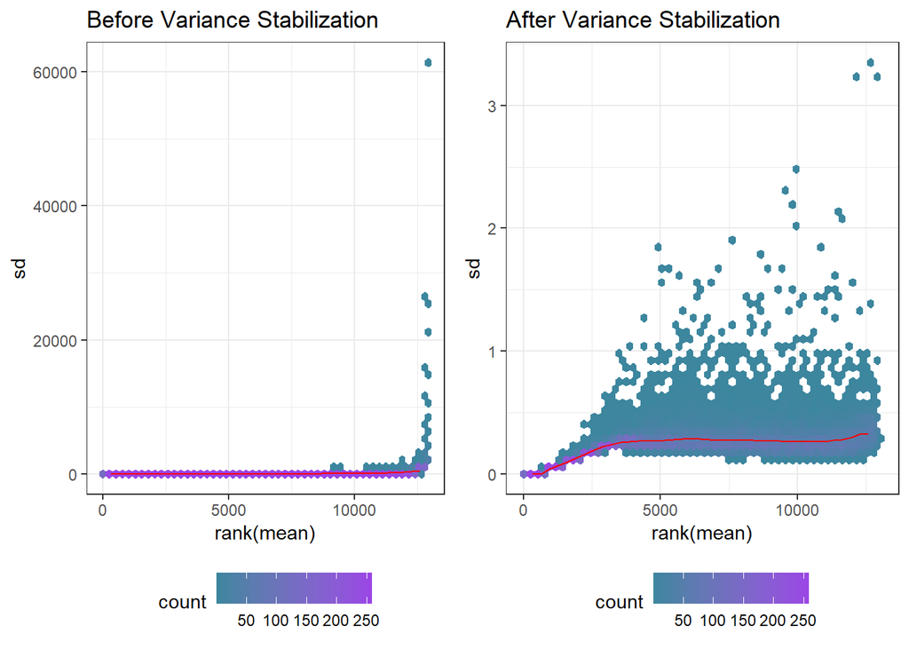

```
## class: DESeqTransform
## dim: 12924 74
## metadata(1): version
## assays(1): ''
## rownames(12924): LOC100740276 LOC100740157 ... LOC112214039
##   LOC100742283
## rowData names(6): baseMean baseVar ... dispGeneIter dispFit
## colnames(74): C00ECK5 C00ECK6 ... T720ECK107 T720ECK108
## colData names(4): Colony Treatment Time sizeFactor
```

```r
runVST(dsgnObject,
       blind = FALSE,
       fitType = "parametric",
       makePlot = TRUE,
       writeTable = FALSE,
       writeRData = FALSE)
```

#### **Question 8**: [1 point]

What do you notice about the plot on the left (the `dsgnObject` without any transformation) vs. the plot on the right after the variance stabilizing transform? Is the VST effective at stabilizing the variance and, if so, how can you tell?

> > MN: Before transformation, we see heterodascity depicted by SD increasing significantly with the mean. After transformation, the SD is much more uniform across the entire range, suggesting the trasnformation was effective at stabilizing the variance.

### 2.3.1 Digging deeper: Estimating gene-wise dispersion

`DESeq2` uses a specific measure of dispersion ($\alpha$) related to the mean ($\mu$) and variance ($\sigma$) of the data: $\sigma^2 = \mu + \alpha * \mu^2$. This means that for genes with moderate to high counts, the square root of dispersion ($\alpha$) equals the Coefficient of Variation ($CV = \sigma^2 / \mu$). Thus, a **0.01 dispersion means there is 10% variation around the mean expected across biological replicates**.

You decide to take a look at the log-log linear relationship between the mean of the counts versus the variance. The relationship between mean and variance should be linear on the log scale, and in gene expression data we predict that for higher means we can more accurately predict the variance (i.e., it is more “fanned out” at lower means and a tighter linear relationship at higher means). We expect that for low mean counts the variance estimates have a much larger spread, such that the dispersion estimates will differ much more between genes with small means. When this pattern holds, a variance-stabilizing transformation *will* help to resolve this issue. This is because the variance stabilizing transformation (VST) functions provided by `DESeq2` attempt to shrink the gene-wise dispersion.

#### Figure 2. Gene expression variance by means.

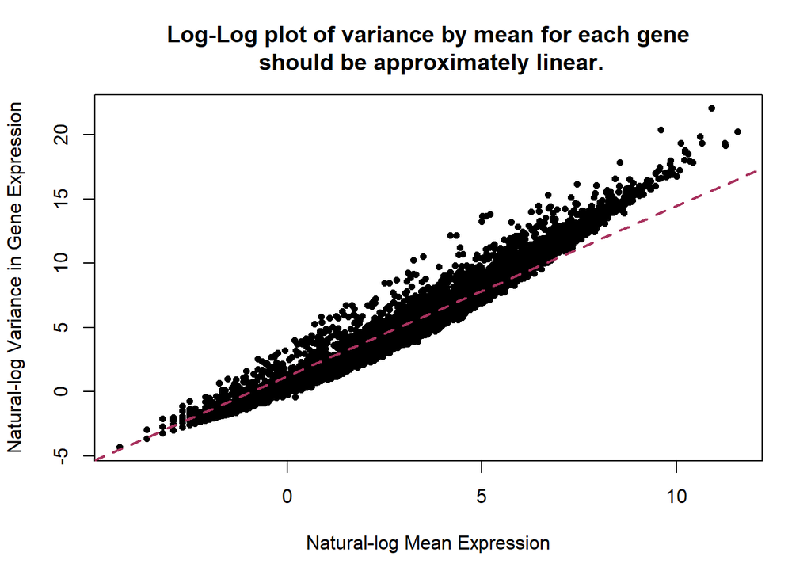

#### **Question 10**: [1 point]

Does this plot support that a VST is (1) needed, (2) not needed, or (3) likely to be ineffective? Please explain.

### Other VST Functions

In the custom wrapper function, `runVST()`, you set the `fitType = "parametric"` when you ran the initial VST. But is this really the best choice? The first rule in GOOD data science (and bioinformatics) is **never just use the defaults!!**

Other functions you could try: - `fitType = "local"`

- `fitType = "mean"`
- `fitType = "rlog"`

#### **Question 11**: [3 points]

Use the custom `runVST()` function, changing out the `fitType` parameter to do some tuning. Heuristically (i.e., assessing just from the visuals you have), which `fitType` seems to be most appropriate here?

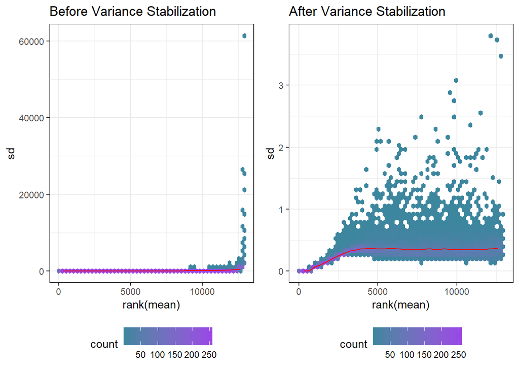

```
## class: DESeqTransform
## dim: 12924 74
## metadata(1): version
## assays(1): ''
## rownames(12924): LOC100740276 LOC100740157 ... LOC112214039
##   LOC100742283
## rowData names(6): baseMean baseVar ... dispGeneIter dispFit
## colnames(74): C00ECK5 C00ECK6 ... T720ECK107 T720ECK108
## colData names(4): Colony Treatment Time sizeFactor
```

```r
runVST(dsgnObject,
       blind = FALSE,
       fitType = "local",
       makePlot = TRUE,
       writeTable = FALSE,
       writeRData = FALSE)
```

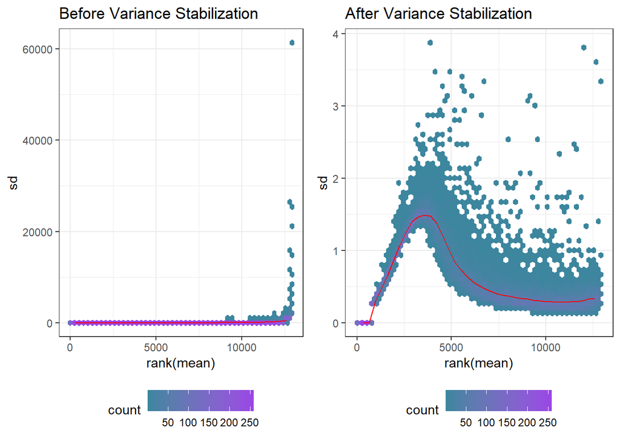

```
## class: DESeqTransform
## dim: 12924 74
## metadata(1): version
## assays(1): ''
## rownames(12924): LOC100740276 LOC100740157 ... LOC112214039
##   LOC100742283
## rowData names(6): baseMean baseVar ... dispGeneIter dispFit
## colnames(74): C00ECK5 C00ECK6 ... T720ECK107 T720ECK108
## colData names(4): Colony Treatment Time sizeFactor
```

```r
runVST(dsgnObject,
       blind = FALSE,
       fitType = "mean",
       makePlot = TRUE,
       writeTable = FALSE,
       writeRData = FALSE)
```

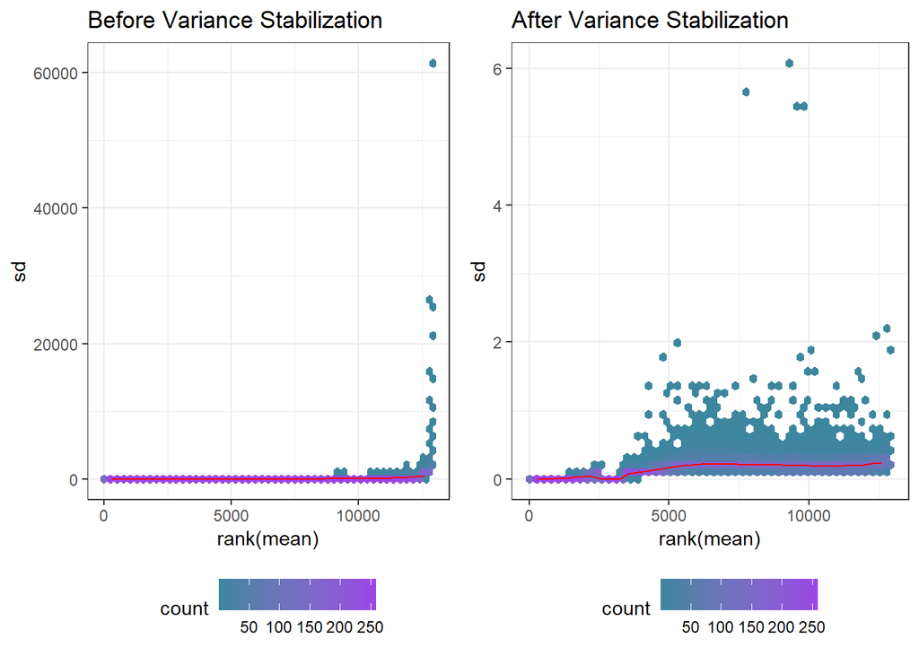

```
## class: DESeqTransform
## dim: 12924 74
## metadata(1): version
## assays(1): ''
## rownames(12924): LOC100740276 LOC100740157 ... LOC112214039
##   LOC100742283
## rowData names(7): baseMean baseVar ... dispFit rlogIntercept
## colnames(74): C00ECK5 C00ECK6 ... T720ECK107 T720ECK108
## colData names(4): Colony Treatment Time sizeFactor
```

```r
runVST(dsgnObject,
       blind = FALSE,
       fitType = "rlog",
       makePlot = TRUE,
       writeTable = FALSE,
       writeRData = FALSE)
```

**FINALLY**, don’t forget to `runVST()` with the `fitType` parameter of your choice!

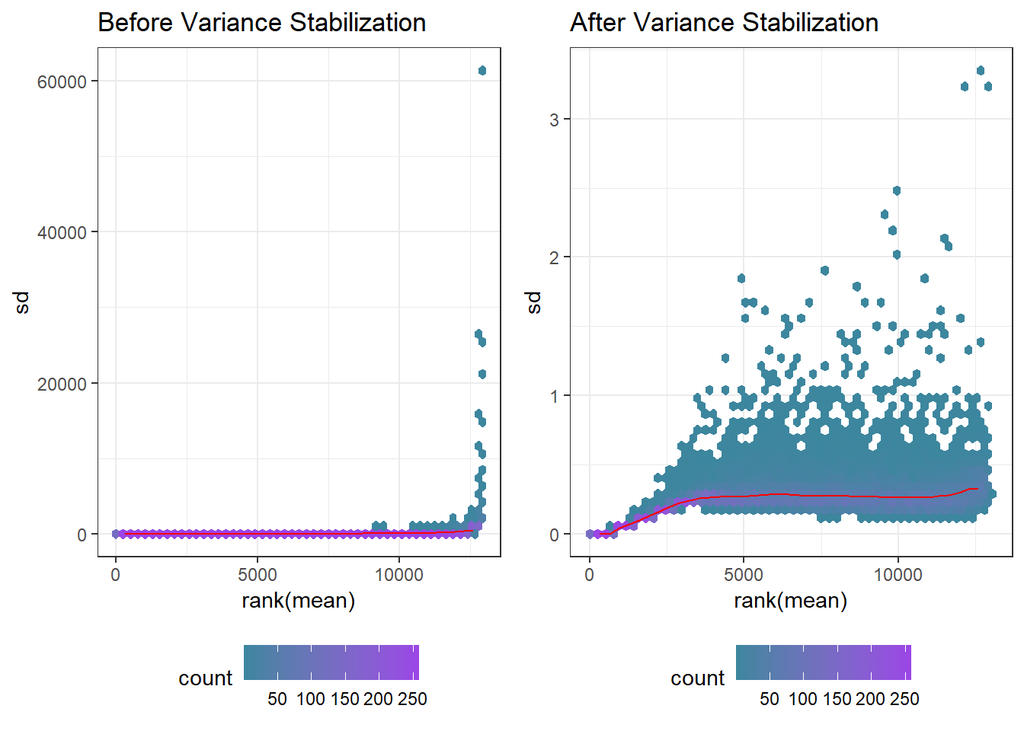

```
## class: DESeqTransform
## dim: 12924 74
## metadata(1): version
## assays(1): ''
## rownames(12924): LOC100740276 LOC100740157 ... LOC112214039
##   LOC100742283
## rowData names(6): baseMean baseVar ... dispGeneIter dispFit
## colnames(74): C00ECK5 C00ECK6 ... T720ECK107 T720ECK108
## colData names(4): Colony Treatment Time sizeFactor
```

```r
runVST(dsgnObject,
       blind = FALSE,
       fitType = "parametric",
       makePlot = TRUE,
       writeTable = FALSE,
       writeRData = FALSE)
```

## 2.4 Finding differentially-expressed genes (DEGs)

You’re only seeing the tail-end of what is a **very** long process to uncover differential gene expression. And yet, your work is only just beginning! The next important thing to understand when we are doing **conventional gene expression** analyses is the concept of **fold-change**. You’re going to explore this a little bit here before we test for significant differential expression of the genes.

The `DESeq()` function does two things roughly simultaneously. It:

1. **Performs normalization (median of ratios).** It does this by correcting for variance in read sequencing depth as well as for inter-library dispersion in counts (for each gene).
2. **Calculates the significance of coefficients with a negative binomial generalized linear model.**

Note that `DESeq2` does not actually use the normalized counts but rather uses the raw counts and *models the normalization in the negative binomial model*. Huh? What this really means is that `DESeq2` does not transform or normalize the counts directly before statistical testing. Instead, it uses raw counts and includes normalization factors internally within the model when estimating differential expression. So, what’s really happening is:

1. `DESeq2` starts with non-transformed, integer read counts (e.g., number of reads mapped to each gene per sample)
2. Then `DESeq2` estimates **size factors** for each sample, which account for differences in library size or sequencing depth. These size factors are a form of scaling factor and are calculated such that the median ratio of observed gene counts across samples is approximately 1 (using the Control samples as the reference sample)
3. Lastly, `DeSeq2` fits a Negative Binomial generalized linear model where $\text{counts}_{ij} \sim NB(\mu_{ij}, \alpha_{ij})$ such that $i$ is the gene, $j$ is the sample, $\mu_{ij} = s_j \cdot q_{ij}$ (the mean of each gene per sample is the product of the size factor, $s_j$ and the underlying expression on a linear scale, $q_{ij}$), and $\alpha_{ij}$ is the gene-specific dispersion. And if this all gets too mathy for you, never fear: **Just know that what it is doing is putting the normalization (size) factor $s_j$ directly into the model**. Whew!

Well, why on earth does all this even matter then? **We need this to get to our ultimate goal: to figure out which genes are significantly differentially expressed in a statistical sense.** Once we have the counts modeled in this way, we can do statistical tests to figure out which genes are significantly different between our treatment and control, as well as the time points, while controlling for the batch (colony) effects. Not only that, but we can also assess the **magnitude** of the differential expression and ask which genes are the “most different” between treatments, across all the time points and after controlling for batch effects?

### 2.4.1 Assessing magnitude with log-fold change (LFC)

Although **we will actually calculate magnitude below**, I first want to introduce what it is here. In gene expression studies, there a few ways to judge the **magnitude** of significant differential expression, but the most conventionally used is **fold-change**, specifically the **log** of the fold-change. **Log-fold change** refers to the fold-change on a logarithmic scale to indicate a positive or negative change in expression between two conditions. As a reminder, here you are comparing the **cold-exposed** (chill coma) treatment to the **control** treatment. Thus, a positive fold change value correlated with increased expression in cold-exposed vs. control whereas a negative fold change indicates a decrease in expression in the cold-exposed treatment relative to control.

However, this value is typically reported in $log_2$, and our human brains do not do on-the-fly conversions of logarithms very well. So, first let’s make ourselves a little cheatsheet to help with this. For example, a $log_2$-fold change of 2 for any given gene in our study would mean that the expression of that gene is increased (**up-regulated**) in **cold-exposed** bees relative to **control** bees, on average, by a multiplicative factor of $2^2 \approx 4$!

#### Figure 3. Relationship between log-fold and linear change.

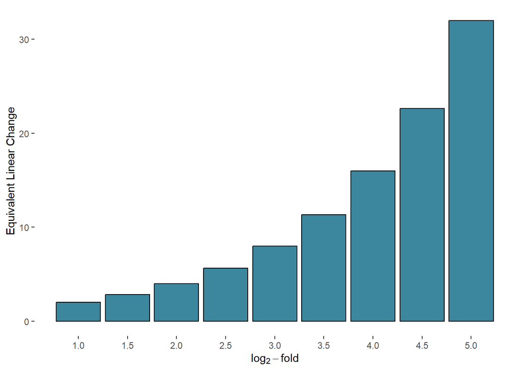

Table 2. Cheatsheet of log-fold change with linear scale equivalents.

| log2-fold Change | Linear Equivalent |
| --- | --- |
| 1.0 | 2.000 |
| 1.5 | 2.828 |
| 2.0 | 4.000 |
| 2.5 | 5.657 |
| 3.0 | 8.000 |
| 3.5 | 11.314 |
| 4.0 | 16.000 |
| 4.5 | 22.627 |
| 5.0 | 32.000 |

**UP-REGULATION and DOWN-REGULATION** Why do we call increased and decreased expression up- and down-regulation, respectively? The idea is that, if there is higher expression in the treatment condition (here, the cold-exposed or chill coma) vs. the control, then that means that transcribed more mRNA in the treatment. This is thought to imply that gene expression has been turned “up” or even “on”, so in our case it would mean that going into chill coma (which we might expect to DECREASE gene expression since it’s a coma - but we don’t know!) would turn up expression over what happened it in the control bumblebees. Conversely, down-regulation suggests that genes have been turned down (or even off!) in the chill coma condition relative to control. Positive $log_2$-fold change indicates up-regulation genes, negative LFC indicates down-regulation, and an LFC of zero would mean effectively no change in magnitude.

Previously, it was thought that only high magnitude changes in gene expression matter physiologically, but we now know that to be untrue. Even *small* changes in magnitude can be significant, meaning that even subtle increases or decreases in expression can indicate something biologically meaningful happening in an organism in response to treatment. Still, some biologists will choose to focus over-hard on only the high magnitude changes!

#### **Question 12**: [1 point]

Suppose that Gene A has a $log_2$-fold change of -4 in the chill-coma bumblebees versus the control bees. If a *positive* $log_2$-fold change indicates **up** regulation of a gene (a gene getting turned on) and a *negative* $log_2$-fold change indicates **down** regulation of a gene (the gene getting turned off) in the chill coma bees versus the control, on average.

Use the information in the cheatsheet (or calculate it directly) to find the approximate multiplicate factor in gene expression change in the chill coma bees versus the control bees.

> MN: So according to the chart a log2-fold change of 4 corresponds to a 16x increase, so a log2-fold change of -4 would be a downregulation of 16.

If a second gene, Gene B, shows a $log_2$-fold change of +3, how does the direction and magnitude of Gene B’s expression change compared to Gene A in chill coma vs. control bumblebees?

> MN: A log2-fold change of +3 is an 8x increase. So, Gene B upregulates 8x higher in chill coma vs control. Gene A shows a downregulation in comparison.

### 2.4.2 Wald Tests for significant differential expression between conditions

Although you already specified the design matrix — which defines the contrasts you’re interested in — you still don’t know which genes are differentially expressed. To identify those genes, you need a formal, standardized approach to retrieve DE genes: hypothesis testing using significance thresholds. This is where the Wald test comes in. `DESeq2` uses the Wald test to determine, for each gene, whether the difference in expression between chill coma–treated bees and control bees is statistically significant. This is done gene by gene, comparing whether the estimated $log_2$-fold change (LFC) differs significantly from zero.

If “Wald test” sounds familiar, it should! You’ve encountered it before in linear regression models. The Wald test is a statistical test used to assess whether a model coefficient, like a slope (beta) coefficient, differs significantly from zero. So, every time you’ve tested whether a slope (beta coefficient) was significantly non-zero in a linear regression, you’ve been doing a Wald test, whether you realized it or not!

In your differential gene expression analysis, the Wald test will evaluate for each gene whether the difference in expression between cold-exposed and control bees is statistically significant (based on a Benjamini-Hochberg adjusted $p < 0.05$) AND the magnitude of the difference meets a $log_2$-fold change (LFC) threshold. Rather than selecting a single arbitrary LFC cutoff, you’ll explore a range of LFC values to see how the number of differentially expressed (DE) genes changes depending on how large a change you consider biologically meaningful. (**Spoiler**: many published studies still pick a single threshold without justification — but we’ll do better than that!)

Note that this is a more conservative approach than you will see in some papers because you are using the Wald test. The alternative is to just perform what is called **post-hoc filtering**, which is based on $log_2$-fold change (LFC) threshold ONLY. This means that you are very likely to find fewer genes than with the post-hoc filtering method. However, since your **ultimate goal is benchmarking**, using the more conservative method will give you a standardized approach that can be used over and over without bias - even if it leads to fewer DE genes.

#### 2.4.2.1 Load in the correctly normalized data

Although you made your choice in Question 11, so that we are all on the same page I will have you read in the data so as not to give away the correct answer!

```r
load("vst_all_timepoints.Rdata")
```

#### 2.4.2.2 Estimate the size factors

```r
## Yes, we are overwriting our object after scaling for convenience.
dsgnObject <- estimateSizeFactors(dsgnObject)

## If we wanted to see the resulting size factors employed for each sample
# dsgnObject@colData$sizeFactor
```

Let’s examine how well the scaling/normalization has worked across all of the samples:

#### Figure 4. Effect of scaling / normalization across all 74 samples.

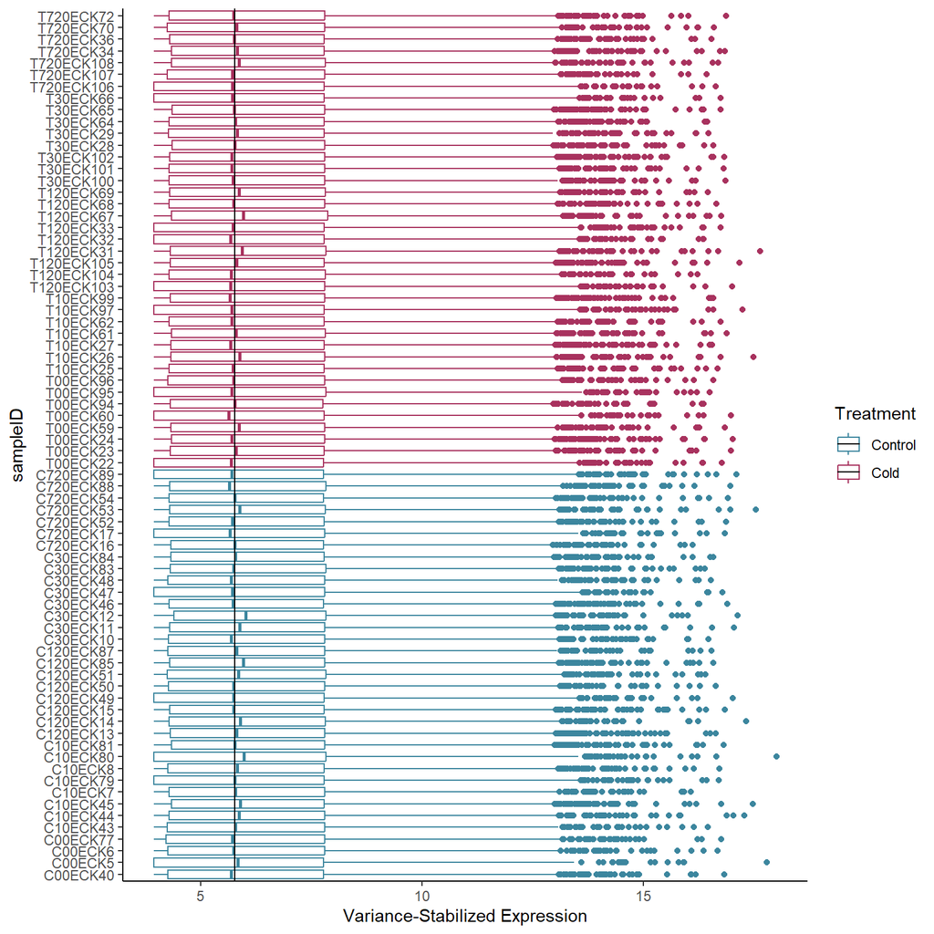

#### **Question 13A**: [0.5 points]

How well did the scaling do that I chose? Make sure to look at it across not only all samples but also whether those samples are from the Control vs. the cold-exposed Treatment groups. Are you concerned about any of the samples specifically? Why or why not?

> MN: From the generated plot, I believe the scaling looks solid. There seems to be uniformity, without any major difference in the overall trends. Between the cold vs control groups, it’s very hard to tell, but the control seems to show some slight shifting vs the control.

#### 2.4.2.3 Let’s FINALLY call significantly DE genes!

We will finally loop through a set of LFC values and perform Wald tests to see which genes are significantly differentially expressed between the treatment groups using tha FDR-adjusted $p$-value of 0.05. **NOTE**: Be patient, this could take up to a minute to run on your machine.

```r
## Setting this for a False Discovery Rate of 5%
alpha <- 0.05
## Estimate the dispersions
dispObject <- estimateDispersions(dsgnObject)
## Use that to perform the negative binomial Wald tests
waldObject <- nbinomWaldTest(dispObject)

## Define a vector of LFC thresholds to try
lfc_thresholds <- c(0, 1, 1.5, 2)

## Loop through each threshold and summarize how many DE genes meet the cutoff
for (lfc in lfc_thresholds) {

  ## Extract results at the given LFC threshold & FDR-adjusted p-values
  res <- results(waldObject,
                 alpha = alpha,
                 ## Uses Benjamini-Hochberg / FDR adjusted p-values
                 pAdjustMethod = "BH",
                 lfcThreshold = lfc)

  ## Print the summary of DE genes at this threshold
  print(paste0("----- LFC threshold:", lfc, "-----"))
  print(summary(res))

  ## Optional: save or store each result if needed
  assign(paste0("results_LFC_", lfc), res)  ## to save each result
}
```

```
## [1] "----- LFC threshold:0-----"
##
## out of 12177 with nonzero total read count
## adjusted p-value < 0.05
## LFC > 0 (up)       : 85, 0.7%
## LFC < 0 (down)     : 123, 1%
## outliers [1]       : 35, 0.29%
## low counts [2]     : 3044, 25%
## (mean count < 2)
## [1] see 'cooksCutoff' argument of ?results
## [2] see 'independentFiltering' argument of ?results
##
## NULL
## [1] "----- LFC threshold:1-----"
##
## out of 12177 with nonzero total read count
## adjusted p-value < 0.05
## LFC > 1.00 (up)    : 1, 0.0082%
## LFC < -1.00 (down) : 0, 0%
## outliers [1]       : 35, 0.29%
## low counts [2]     : 0, 0%
## (mean count < 0)
## [1] see 'cooksCutoff' argument of ?results
## [2] see 'independentFiltering' argument of ?results
##
## NULL
## [1] "----- LFC threshold:1.5-----"
##
## out of 12177 with nonzero total read count
## adjusted p-value < 0.05
## LFC > 1.50 (up)    : 1, 0.0082%
## LFC < -1.50 (down) : 0, 0%
## outliers [1]       : 35, 0.29%
## low counts [2]     : 0, 0%
## (mean count < 0)
## [1] see 'cooksCutoff' argument of ?results
## [2] see 'independentFiltering' argument of ?results
##
## NULL
## [1] "----- LFC threshold:2-----"
##
## out of 12177 with nonzero total read count
## adjusted p-value < 0.05
## LFC > 2.00 (up)    : 1, 0.0082%
## LFC < -2.00 (down) : 0, 0%
## outliers [1]       : 35, 0.29%
## low counts [2]     : 0, 0%
## (mean count < 0)
## [1] see 'cooksCutoff' argument of ?results
## [2] see 'independentFiltering' argument of ?results
##
## NULL
```

```r
## Save the results, if needed (after identifying which one is your best result)
 ## save(myBestResults, file = "DESeqResults.Rdata")
```

#### **Question 13B**: [0.5 points]

You know what a p-value is but you may not be familiar with an **adjusted p-value**. What is it? Specifically, what’s a **False Discovery Rate (FDR)**? In general, why would you choose to use an FDR over a p-value? Is this more broadly applicable in data science outside bioinformatics, do you think?

> MN: An adjusted p-value accounts for doing many statistical tests at once. You would choose FDR over p-value because it is more powerful when working with RNA data. I think FDR could be useful when you are trying to test many diffrent theories or hypotheses at one time.

#### **Question 13C**: [0.5 points]

How many total genes were assessed for differential expression? (Use the `summary()` outputs from the loop.)

> MN: 12177 genes were assesed.

#### **Question 13D**: [0.5 points]

Which $log_2$-fold change (LFC) threshold yieled the most differentially expressed genes? The least? Why? Which LFC is the BEST choice to use? (Use the `summary()` outputs from the loop.)

**NOTE**: Not all studies will use a LFC threshold. I have published studies in the past where I focused on only the FDR-adjusted $p$-value but didn’t worry as much about magnitude. Can you think of a **biological reason** why we might not worry as much about magnitude as overall effect in a case like this? (**Hint**: If genes are only turned on or off briefly, there may not be enough time for a LOT of mRNA transcripts to be made! We also tend to think, erroneously, that large magnitude == “important”, but there are many biological functions that just need a “sufficient” signal, they don’t need to be flooded in it! Feel free to reach out if you want me to explain this more deeply.)

> MN: The LFC threshold that yielded the most differentially expressed genes was 0, with 85 genes up regualted and 123 down regulated. The least expressed genes were 1, 1.5, and 2 with similar results of 1 upregualted gene, and 0 down regulated. Considering most of the LFC results were the same, I think 1 would be the best choice. While 0 shows many more genes identified, 0 is much more sensitive and will include a wider range of numbers. LFC of 1 could show more biological significance.

#### **Question 14**: [1 point]

Based on your answers to Question 13C-D, how many differentially expressed genes did we find with the **Wald test**?

> MN: 208 total genes were found to be differentially expressed.

#### **Question 15**: [1 point]

Looking at the Verble et al. (2023) study, how do our results differ from their `DESeq2` results and why do you. think that might be?

**Hint 1**: What is different about our **design formula** versus what they describe verbally? **Hint 2**: Look at what we did with `Time`!

> (JML) Our design formula uses Colony + Time + Treatment, but the study identifies their best DESeq2 design formula as Treatment Only (thus dropping Time completely from the analysis)

# 3 Exploratory Data Analysis

After all that hard work, it feels pretty disappointing to find so few genes differentially expressed between cold-exposed and control treatments across all the time points. Let’s start to visually explore the data to see if there is enough here to apply a machine-learning approach to help us out. After all, remember that **Wald tests** are very conservative! They are also not going to do as good a job at cutting through noise, regardless of scaling & normalization.

## 3.1 Summary statistics on the raw gene (feature) counts

Let’s first go back to the raw data to see if there’s anything diagnostic here. For example, if we had genes with a low proportion of counts or a big bias in mapped reads between treatments, that could indicate a problem with the expression data.

Table 3. Summary statistics of the raw gene expression counts

|  | All Samples |
| --- | --- |
| Total Genes | 12924 |
| Number Genes with >1 read count | 12177 |
| Proportion with Nonzero Expression | 0.9422 |
| Proportion with Low Expression | 0.3940 |
| Number Reads: Cold-Expossed Treatment | 162407437 |
| Number Reads: Control Treatment | 153494007 |
| Total Reads Mapped | 315901444 |
| N Samples | 74 |
| Mean CPM per Sample | 4.27 |

#### **Question 16**: [1 point]

Look at the custom function I’ve written for generating the summary statistics. How is **low expression** defined? What proportion of all reads had low expression? Does this seem high? Should we do any filtering to remove low-expression genes, do you think?

> (JML)To me, yes, the 39% of all reads having low expression does seem high. However, the suggestion that low expression might be a byproduct of the treatment seems to be reasonable to me, so I don’t think removing them would be a good idea.

**Hint**: If it seems high, remember that the bumblebees were put into a **chill coma** (which means their physiological processes might have shut down). In other words, the low expression might be a byproduct of the type of treatment that was applied and could be really interesting in and of itself. Conventional methods typically **remove lowly expressed genes**, but is that what we want to do here?

## 3.2 Heatmap of gene expression across treatments & time points

Next, you will calculate the sample distances using a Pearson’s pairwise correlation coefficient as you have typically done in your EDA to date. The `cor()` function can be applied to the matrix of normalized gene expression values and then we can make a heatmap using the `pheatmap` package. Notice that you are also applying **hierarchical clustering**, which means that you are clustering the samples by correlation coefficient. Note that to get the matrix of numeric values for input, you extract them from the VST object containing our normalized values using the `assay()` function.

#### Figure 5. Gene expression correlation among the samples with hierarchical clustering.

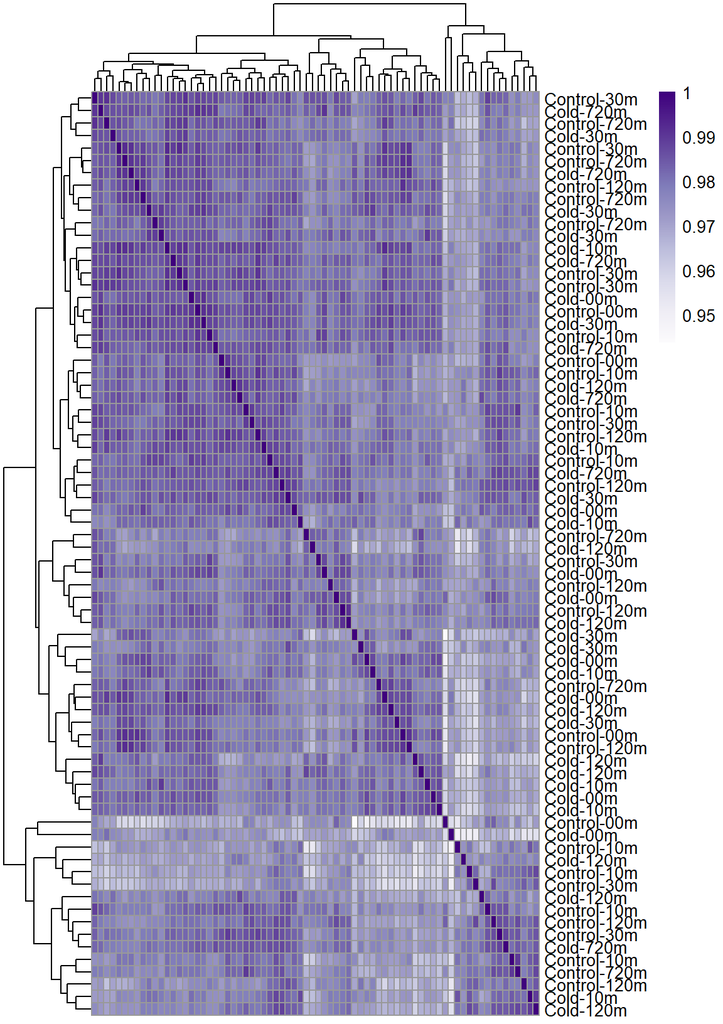

#### **Question 18**: [1 point]

From the heatmap, what do you notice about the arrangement of the treatments and time points (or lack thereof)? Do you see any important patterns that might explain why so few differentially expressed genes have been identified with `DESeq2`?

> (JML) I believe that the heatmap is showing a great deal of collinearity. I struggle to find patterns that hint at being able to easily separate one feature from another. To me, that is why there are so few differentially expressed genes.

#### **Question 19**: [2 points]

Complete this code chunk to calculate the sample distances instead. You will use the `dist()` function, which calculates the Euclidean distance between samples but to do it you must first **transpose** the matrix with the `t()` function. This is actually somewhat similar to what is happening in a k-means clustering algorithm. Does your assessment about the arrangement of the treatments and time points change any?

> (JML) This plot seems to reduce some of the collinearity between variables, and it is a bit easier to see some patterns than in the Q18 plot.

**Hint**: Make sure to update your figure caption!

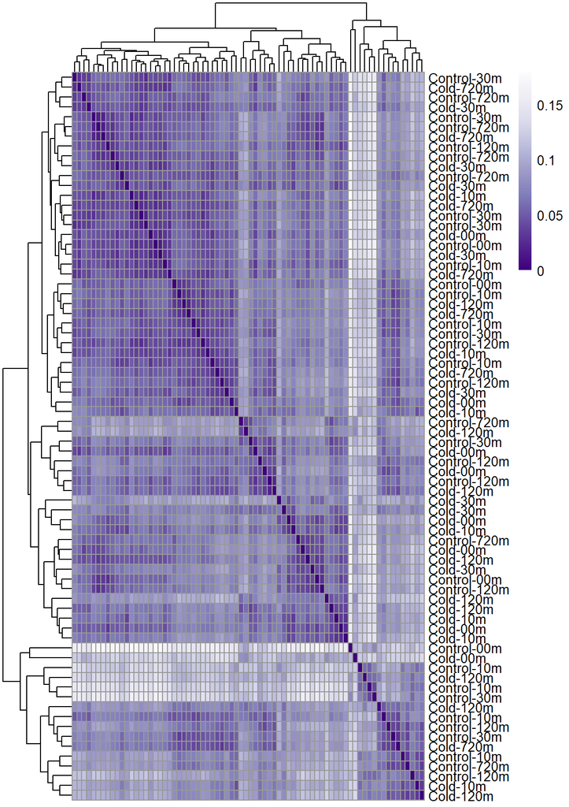

```r
## Calculate the sample distances; fill in the blank and take off the comment to run
sampleDistances <- dist(t(pwCorr))     ## Hint: what did we do to extract a matrix from the VST object earlier?

## Make the heatmap of the sample distances; fill in any blanks and then take the comments off to run!
sampleDistMatrix <- as.matrix(sampleDistances)

## Let's label by treatment and time again
rownames(sampleDistMatrix) <- paste(vsData$Treatment, vsData$Time, sep="-" )
colnames(sampleDistMatrix) <- NULL

## Let's set a monochromatic color palette
colors <- colorRampPalette(rev(brewer.pal(9, "Purples")))(255)

pheatmap(sampleDistMatrix,
         clustering_distance_rows = sampleDistances,
         clustering_distance_cols = sampleDistances,
         col = colors)
```

## 3.3 Principal Component Analysis (PCA)

As you did in Project 1, we will perform a PCA again! PCA is also very commonly performed in gene expression studies because it allows you to visualize how well you different samples and conditions cluster together. You can also use PCA to identify which genes are likely to be more important to explain those differences, although you will not employ that here. Most importantly, given how **noisy the heatmap looks**, it would be nice to see if you can ‘cut through the noise’ with any other methods!

Notice that you are using a `plotPCA()` function which has been designed to work with gene expression data rather than `princomp()` or `prcomp()`, as was done in Project 1 or as you may see in other `R` resources on PCA. But could you still use `princomp()` or `prcomp`? Technically, yes, but not without a lot of reformatting and other work. `plotPCA()` is specifically designed for RNA-seq data because it expects an object like your variance-stabilized transformed (VST) count matrix (it will also accept a regularized-log or `rlog` count matrix), so you know that the data have been prepared appropriately for expression analysis. `plotPCA()` is also designed to automatically use the **most variable genes**, which are usually the most informative for separating samples. Recall that `princomp()` assumes continuous, normally distributed variables; since raw counts from RNA-seq are overdispersed and non-normal, this would prove problematic. Yet, traditional normalization techniques would NOT be appropriate for gene expression data, either! [And be wary of anyone you see doing it that way!]

So, to do the PCA on the VS-transformed read counts, it’s pretty straightforward. First, you will want to make sure that the factor `Time` is in chronological order - this is just for your visualization. Then, you use the `plotPCA()` function to create a dataframe that includes principcal components 1 and 2, as well as your metadata and the size factors. I also like to round the percent variance attributable to the principal components just show it’s cleaner on the plots. Lastly, we can plot PC2 vs. PC1, as we’ve done prior, but I also opted to facet by the timepoints to better visualize the effects of chronological sampling.

#### Figure 7. The first two principal components for the difference in gene expression across all samples, conditions, and time points.

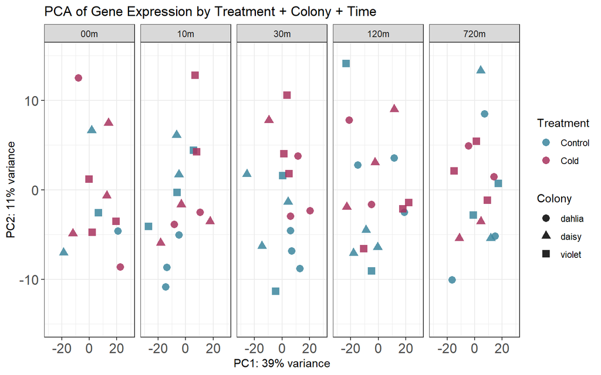

#### **Question 20**: [1 point]

What percent of the variance is attributable to PC1 and PC2? At which time point(s) do you see the most separation between the treatments? Is this consistent with what Verble et al. (2023) found?

> (JML) The percent variance attributable to PC1 and PC2 is 50%. I see the most separation between treatments at 30 minutes. My understanding of the discussion in the Verble paper indicates that the separation would occur at 10 minutes, but I admit I’m not completely understanding all the terminology in the paper.

#### **Question 21**: [1 point]

Think about what we discussed in lecture about Support Vector Machines. Do you see anything in these PCA plots that make you think that SVM might do a much better job of finding the decision boundary between the treatments than the negative binomial generalized linear regression model that `DESeq2` used? (**Hint**: If you can’t “see” it, look at the slide from lecture about a non-monotonic decision boundary. Do you think it’s possible that there is a non-monotonic boundary between the treatments here because of `Time`?)

> (JML) Yes, I think that SVM could provide better information than the PCA and the negative binomial glm because 1) there is a high number of variables in this data, and 2) there doesn’t appear to be a clear, linear relationship between time and treatment.

## 3.4 Volcano Plots

A volcano plot is a type of scatter plot used in gene expression analysis to visualize the relationship between statistical significance (usually the $-log_{10}$ of the adjusted $p$-value) and magnitude of change (typically the $log_2$-fold change) for each gene. Points higher on the plot and toward the corners indicate genes with stronger statistical significance (small FDR-adjusted $p$-values), making it easy to identify genes with *both* large expression changes and strong statistical evidence.These are the most **canonical plots** (along with clustered heatmaps) for visualizing the results of gene expression analyses.

Recall from earlier that **up-regulated** genes are those that show higher expression levels in one condition compared to another (e.g., treated vs. untreated). We typically think that this means the gene is more “active” or transcribing more mRNA in the treated condition. Here, that would mean we think bumblebees are either ramping up or even turning ON a gene in response to chill coma as opposed to turning it off or down! A positive $log_2$-fold change indicates up-regulated genes, so these genes will appear on the **right** of the volcano plot.

In contrast, genes that are significantly down-regulated appear on the left (negative $log_2$-fold change) of the plot. Down-regulated genes are expressed less in the treatment condition compared to the control; we typically think of these genes as less active, thereby producing less mRNA, and have potentially been turned down or even off. Here, that would mean we think bumblebees are either ramping down or even turning OFF a gene in response to chill coma!

Thus, volcano plots allow you to quickly visualize the same results you saw from the Wald tests, including how many genes’ expression was turned up/on in the chill coma treatment relative to the control state vs. genes turned down/off.

#### **Question 23A**: [0.5 points]

Using your answer to Question 13B, set the $log_2$-fold threshold in the code below. To do this, change out the number of the vector that corresponds to your selection in the earlier question. By default, I am choosing a $log_2$-fold threshold of 2. **Remember**: R is a one-referenced language, whereas Python is a zero-referenced language. This means that, in R, the fourth element in a vector will be `myVector[4]` in R!

```r
## print(lfc_thresholds) ## Uncomment to view

## Change the number of the vector to update
lfc <- lfc_thresholds[1]
```

```r
#volcano$log2FoldChange
```

*The first step is to take the results and turn it into a dataframe containing the relevant information for plotting. This includes defining when genes will be up-regulated or down-regulated!*

```r
## Re-run the results with the specified LFC:
res <- results(waldObject,
                 alpha = alpha,
                 ## Uses Benjamini-Hochberg / FDR adjusted p-values
                 pAdjustMethod = "BH",
                 lfcThreshold = lfc)

## First, make a data frame of the results
volcano <- res %>%
  as.data.frame() %>%
  ## Annotate anything that is significant by the Wald test
  ## It's a differentially expressed gene (DEG) between the conditions if the
  ## adjusted p-value is less than 0.05; further, calling up-regulated if the
  ## log2-fold change threshold is positive and down-regulated if the LFC is
  ## negative
  mutate(DEG = ifelse(log2FoldChange > lfc & padj < 0.05, "Up-regulated",
             ifelse(log2FoldChange < lfc & padj < 0.05, "Down-regulated", "N.S."))) %>%
  drop_na()    ## We have to drop the NAs for Volcano plots, unfortunately!

## Next, annotate anything with greater then the log-fold cutoff change in
## expression:
volcano <- volcano %>%
  mutate(locus = ifelse(abs(log2FoldChange) > lfc &
                          DEG != "N.S.", rownames(res), ""))
```

#### Figure 8. Volcano plot of gene expression between cold-exposed and control bumblebees.

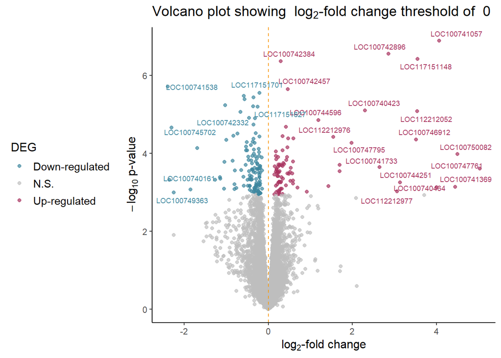

```r
#need to remove
volcano %>% filter(locus == "LOC100742138")
```

```
## [1] baseMean       log2FoldChange lfcSE          stat           pvalue
## [6] padj           DEG            locus
## <0 rows> (or 0-length row.names)
```

```r
#need to remove
unique(volcano$locus)
```

[output not shown]

[output cut: 27 more lines]

On the above volcano plot, the y-axis is the $-log_{10}$ $p$-value and the x-axis is the $log_2$-fold change. The dashed gold lines show where $log_2$-fold change between the chill coma and control conditions is $\geq 2$, which is would mean that expression is $2^2$ times greater in one condition over the other in linear change. Thus, the interpretation of this volcano plot (as printed using `lfc <- lfc_thresholds[4]`, which MAY or MAY NOT be your selection from Question 23A!) is that there is a single gene, `LOC100742138`, significantly up-regulated in the chill coma condition relative to the control condition such that expression was more than 4 times in the chill coma condition as control. **Note** that I have used `ggrepel()` to annotate genes with a $log_2$-fold change of greater than the threshold.

#### **Question 23B**: [1.5 points]

**Interpret** your version of the volcano plot using the $log_2$-fold change threshold from Question 23A. Does the same gene `LOC100742138` appear to be significantly differentially expressed (and up-regulated) regardless of which LFC threshold you choose? (If you’re not sure, look for it in the `volcano` dataframe!). Why is this?

> (JML) In Q13B, I selected LFC threshold of 0.0, so the index used in the volcano plot is 1. The gene `LOC100742138` does not appear to be significantly differentially expressed in LFC threshold of 1.

What happened to the dashed gold line in your plot vs. the one I made? (Refer back to the HTML document if needed). Why did this happen?

> (JML) If I’m understanding this properly, when the log2-fold change is 2, the LFC threshold is also 2, so the gold lines in Figure 8 are drawn at +/-2. For our LFC threshold of 0, there would only be one line at the 0 log2-fold mark.

# 4 Machine Learning Analyses

Thus far, you have likely been primarily exposed to the **kitchen sink** model of algorithm selection. That’s pretty common in many applications of data science. In some fields, however – like biology and biomedicine – folks can sometimes be a little more hesitant to just ‘throw anything and everything’ at their data. Why?

- It contrasts fundamentally with how biologists think about performing **“science”**.
- They want clear, methodologies that they can understand (transparency is key).
- The statistics involved were not taught to them.
- There is a very real (and sometimes justified) fear over p-hacking and a **fundamental misunderstanding** that optimization (which is what we do in ML) is NOT the same thing.
- Every good analysis requires clearly justified choices.

This leads many scientists to use more conventional methods, like `DESeq2` because they are more validated - and thus more trusted. And there is NOTHING wrong with the conventional approaches – when they work! I’ve published several times using `DESeq2` and I will continue to do so.

So, why would I even consider switching?

One word: **NOISE**.

## 4.1 Random Forest

You will likely recall that Random Forest (RF) is a popular supervised learning algorithm, or learner, with few assumptions about the relationships among variables. As we discussed in Project 1, RF is generally well-suited to capture complex interactions such as those commonly seen in biological systems and can run either a regression or classification.

It is based on the binary decision tree, which progressively splits the samples into two child nodes that maximize how much of the variance in the dependent variable is explained by the predictors. However, as briefly discussed in Project 1, single decision trees tend to over fit the data, i.e., **they tend to generate much better predictions on the training set than on the test set**. Thus, RF uses an ensemble of trees (a forest!) to counteract this overfitting (although note that it NO algorithm is robust to overfitting!). Each tree in the forest uses a random sample of the observations, while only a subset of all features (columns) is assessed for each node split.

Although sometimes called a ‘black box’ algorithm, RF is more explainable than other deep-learning methods. This tends to make researchers a bit more hesitant to use it. However, recall that RF can give you is a scoring of features according to their influence; this is a measure of how **important** the feature was in generating the trees in the forest. The result is a ranked list of features that were important for predicting the outcome.

RF is being used increasingly with gene expression studies because, as an ensemble learning algorithm, it is thought to be useful in what is often referred to as the “large $P$ small $n$” paradigm, where $P$ is the number of predictors and $n$ is the number of observations. You may not fully realize it, but we have just such a $P >> n$ problem here: $n$ is actually the number of **samples** whereas $P$ is the number of genes!

So, let’s see how a Random Forest performs out-of-bag (OOB) on our data with minimal pre-processing, filtering, and no feature selection.

### 4.1.1 Pre-processing the data

This time through, you are doing very minimal pre-processing. You must first extract and transpose the VST data that you got out of `DESeq2`, however:

```r
## Extract the VST data
tVSdata <- t(assay(vsData))

## We do have gene names, e.g., TRNAV-UAC that are malformed for ranger and
## randomForest. We will fix that before proceeding:
for (c in 1:ncol(tVSdata)) {
  colName <- colnames(tVSdata)[c]
  colName <- gsub("-", "_", colName)
  colName -> colnames(tVSdata)[c]
}
```

### 4.1.2 We need to put our other features (Colony, Time) and our outcome (Treatment) into the transposed matrix

Make sure to put Treatment as the last column; that will be useful downstream in the analysis pipeline!

```r
## Create a temporary df of what we need; note that we don't need the
## size factors, though!
df1 <- cbind(colData(dsgnObject)[1],
             colData(dsgnObject)[3],
             colData(dsgnObject)[2])
## Now merge this with the transposed VST data:
tVSdata <- merge(tVSdata, df1, by = "row.names")

## The merge turns back into a dataframe and removes the sample names from the
## rows; let's put them back:
rownames(tVSdata) <- tVSdata[,1]
## Then drop the sample names again
tVSdata <- tVSdata[,-1]

## Make sure that Treatment is a factor in the right order:
tVSdata$Treatment <- relevel(tVSdata$Treatment, ref = "Control")
```

### 4.1.3 Create the test-train partitions using the `createDataPartition()` function from the `caret` package.

This allows you to split with respect to the response variable, Treatment, to ensure that it is even distributed throughout the test-train split. You will see that, with so few samples, I am opting for a 80%-20% split. There is a reason for this; if you calculated this as you’ve done prior, e.g., using the $\sqrt{p}:1$, you would not have sufficient training data, sadly. This is BECAUSE you have a $P >> n$ problem!!!

```r
library(caret)
## Make the train and test partitions:
ind <- createDataPartition(
  y = tVSdata[, c("Treatment")],     ## Treatment is evenly distributed
  p = 0.8,                           ## % into training
  list = FALSE)                      ## don't return a list

## Make training and testing
train <- tVSdata[ind, ]
test <- tVSdata[-ind,]
```

#### Figure 9. Distribution of samples between the training and testing sets.

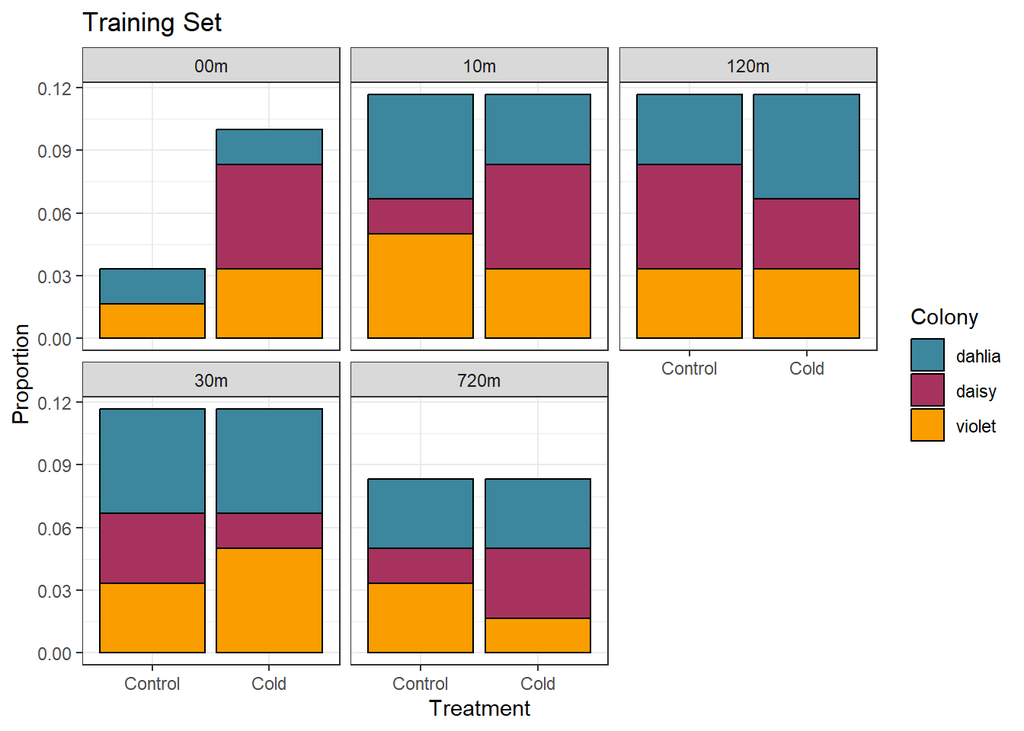

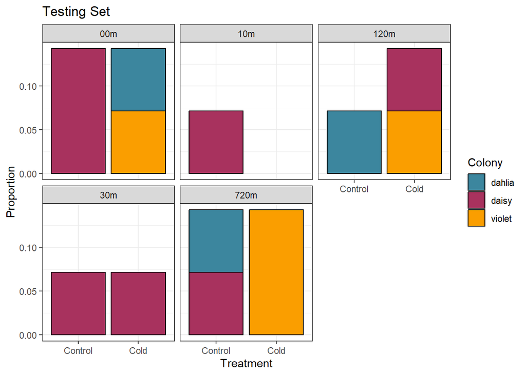

```r
dim(train)
```

```
## [1]    60 12927
```

```r
dim(test)
```

```
## [1]    14 12927
```

#### **Question 24A**: [0.5 points]

How many samples (observations) are in the training and testing data sets? How many features (genes) are there? What is the ratio of predictors (genes) to samples?

> (JML) There are 14 observations in the testing data set and 60 in the training data set. There are 12927 genes. The ratio of predictors to samples is 12927:74 (~175:1)

```r
## Your optional code here.
```

#### **Question 24B**: [0.5 points]

Remember, we used `caret`’s `createDataPartition()` Using Figure 9, do you notice anything concerning about the training split? What about the testing split? Does adjusting the split seem to make it better, worse, or stay the same? **Make sure to change it back after you are finished playing with it.**

> (JML) I noticed that the assignment of treatments within each time range in the testing data set is not as diverse as the assignment within the training data set. When I changed the ratio to 70:30, I saw a mild improvement. When I changed the ratio to 60:40, the diversity was even better.

#### **Question 24C**: [1 point]

What are the predictors in the training and testing sets? Can you guess what the target will be? (**Hint**: This will be a *classification* problem!). If you’re still not sure, think about what you think the roles of `Treatment`, `Time` and `Colony` will be in the model.

> (JML) The predictors in the training & testing sets are the genes. To me, the target is identifying whether the genes are significantly differentially expressed or not, if the goal is a binary classification. I think that Treatment, Time, and Colony could be used to identify important features.

### 4.1.4 Fitting an OOB Random Forest model

Recall from Project 2 that an OOB random forest model is a quick, unbiased estimate of the model fitted to the **training data**. Each decision tree is trained on a bootstrap sample (a random sample with replacement) of the training data such that, on average, about one-third of the data is left out of that bootstrap. The data held out becomes the “out-of-bag” observations for that tree. We can use an OOB with ensemble methods, like random forest, to avoid cross-validation; notably, it can be used for a **quick assessment** of the suitability of a model or how prone to overfitting that model is!

Take a look at the out-of-bag (OOB) performance of a random forest model on the training data. Notice that the model is attempting to classify whether a sample was treated with cold-exposure (chill coma) or control. **This may take your computer a minute (or three) to run. Be patient.**

```r
rfOOB <- randomForest::randomForest(
  Treatment ~ .,  ## Fit against ALL of the predictors (genes) + Time + Colony!
  data = train)   ## Make sure to still use the training set here!
```

Table 4. Results of the OOB Random Forest

|  | Control | Cold | class.error |
| --- | --- | --- | --- |
| Control | 14 | 14 | 0.5000 |
| Cold | 10 | 22 | 0.3125 |

The confusion matrix gives you the OOB classification error of the cold-exposed (chill coma) vs. the reference Control condition.

#### **Question 24D**: [1 point]

How did the model perform? Where is the classification error highest? Does this suggestion a problem with separating the `Cold` class from the `Control` class or not?

You can also plot the results of the OOB RF to assess how well the classes are separated.

#### Figure 10. Result of out-of-bag (OOB) random forest classifier on cold-exposed vs. control changes in gene expression.

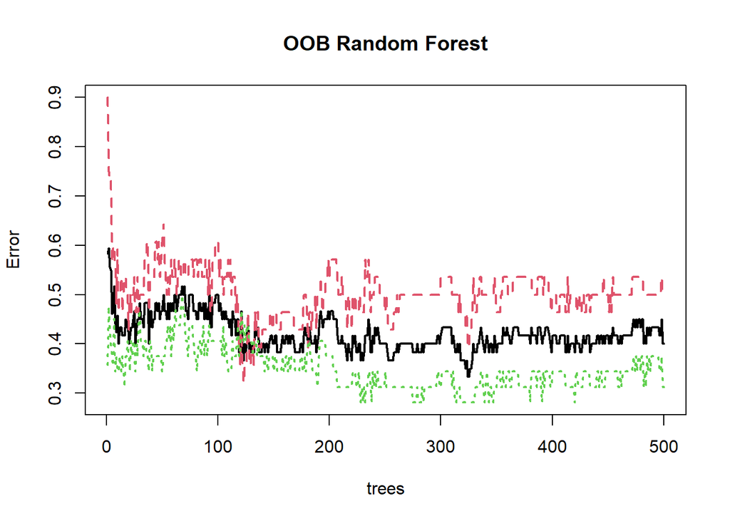

```r
plot(rfOOB,
     main = "OOB Random Forest",
     lwd = 2)
```

#### **Question 24E**: [1 point]

Based on Figure 10, did the OOB RF manage to find complete separation between cold-exposed and control treatments? If yes, approximately how many trees (tree depth) are needed to sufficiently distinguish the `Cold` and `Control` treatment classes? Does this suggest that using 500 trees will significantly improve the model, why or why not?

### 4.1.5 Assessing training vs. testing accuracy

Next, look at the results of the training set when tested against the data (the **training error**):

```r
pred.train.rf <- predict(rfOOB, train, type = 'response')
confMat <- confusionMatrix(train$Treatment,
                pred.train.rf)
```

Table 5. OOB RF Train - Results of Confusion Matrix

|  | overall |
| --- | --- |
| Accuracy | 1.000 |
| Kappa | 1.000 |
| AccuracyLower | 0.940 |
| AccuracyUpper | 1.000 |
| AccuracyNull | 0.533 |
| AccuracyPValue | 0.000 |
| McnemarPValue | NaN |

#### **Question 24F**: [0.5 points]

Look at the results of the training error. What is the accuracy and is this concerning or a good sign?

> (JML) The Accuracy = 100%. I’d be very skeptical of these results because we’ve achieved perfect predictability against the training data, which makes me wonder if we will see overfitting when we look at the testing data set results.

Now, look at the results of the training set when tested against the test set (a.k.a., **test error** from which we derive **model accuracy**):

```r
pred.test.rf <- predict(rfOOB, test, type = "response")
confMat <- confusionMatrix(pred.test.rf, test$Treatment)
print(confMat$table)
```

```
##           Reference
## Prediction Control Cold
##    Control       5    2
##    Cold          2    5
```

Table 6. OOB RF Test - Results of Confusion Matrix

|  | overall |
| --- | --- |
| Accuracy | 0.714 |
| Kappa | 0.429 |
| AccuracyLower | 0.419 |
| AccuracyUpper | 0.916 |
| AccuracyNull | 0.500 |
| AccuracyPValue | 0.090 |
| McnemarPValue | 1.000 |

### 4.1.6 Extracting Important Genes from an OOB Random Forest model

Even though it’s a severely underperforming model in terms of predicting outcomes from unseen data (test accuracy), we can still extract the top **important features**:

```r
importantRF <- rfOOB$importance     ## Store the most important genes!
```

Table 7. Top 10 important genes identiftied by the OOB Random Forest

|  | MeanDecreaseGini |
| --- | --- |
| LOC100744751 | 0.1030959 |
| LOC100745204 | 0.1014580 |
| LOC100747754 | 0.1009642 |
| LOC105680701 | 0.0979910 |
| LOC100740663 | 0.0952136 |
| LOC100743631 | 0.0922944 |
| LOC100746804 | 0.0869063 |
| LOC100740150 | 0.0806433 |
| LOC100744675 | 0.0785075 |
| LOC100748804 | 0.0756574 |

#### **Question 25**: [3 points]

Write code that will compare the resulting important genes from the RF (**Hint**: take the `Mean Decrease Gini` that is greater than 0) and compare that to the genes stored in `res` that are **significant DE genes per** `DESeq2`. How many overlapping genes did you find and what % overlap is that? (**Hint 2**: You may find `anti_join()` (to find differing rows) or `intersect()` (to find overlapping rows) helpful here.)

**Hint 3**: Don’t forget to make sure to filter the `DESeq2` results for signifiance using the adjusted $p$-value!

**Hint 4**: You may find it helpful to turn `importantRF` into a dataframe first; note that the genes are in the *rownames*.

```r
#using a test lfc value; this didn't seem to make a difference though :(
lfcx = 4

# for Gini
rfOOBdf <- importantRF %>%
  as.data.frame() %>%
  filter(MeanDecreaseGini > 0)

rfOOBvector <- rownames(rfOOBdf)

# for DEG
resdf <- res %>%
  as.data.frame() %>%
  mutate(DEG = ifelse(log2FoldChange > lfcx & padj < 0.05, "Up-regulated",
              ifelse(log2FoldChange < -lfcx & padj < 0.05, "Down-regulated", "N.S."))) %>%
  drop_na %>%
  filter(DEG != "N.S.")

resdfvector <- rownames(resdf)

# to compare
same_between_both <- intersect(resdfvector, rfOOBvector)
print(same_between_both)
```

```
## character(0)
```

#### **Question 26**: [2 points]

Now, modify your code from Question 25 into a function. Your function should take at least two arguments:

1. a log-fold change cutoff for the `DESeq` results
2. (Optional) you may choose to add a p-value cutoff for significance.
3. a list of important genes from RF or another machine learning algorithm.

Show that your function works for a LFC cutoff of 1 and the same important genes from the OOB RF, `importantRF`.

**Hint**: I get 9 total overlapping genes when I do this!

> (JML) I made this function based on my attempt on Q25, which doesn’t yield the correct results. If the code on Q25 does get changed, we’ll need to update this function code as well.

```r
# (JML)
compare_gene_vectors <- function(lfc_input, pval_input = 0.05, rf_input) {
# for Gini
  rfOOBdf <- rf_input %>%
    as.data.frame() %>%
    filter(MeanDecreaseGini > 0)

  rfOOBvector <- rownames(rfOOBdf)

  # for DEG
  resdf <- res %>%
    as.data.frame() %>%
    mutate(DEG = ifelse(log2FoldChange > lfc_input & padj < pval_input, "Up-regulated",
                        ifelse(log2FoldChange < -lfc_input & padj < pval_input, "Down-regulated", "N.S."))) %>%
    drop_na %>%
    filter(DEG != "N.S.")

  resdfvector <- rownames(resdf)

  # to compare
  same_between_both <- intersect(resdfvector, rfOOBvector)
  print(same_between_both)
}

# Print
  cat("Number of overlapping genes:", length(same_between_both), "\n")
```

```
## Number of overlapping genes: 0
```

```r
  pct_overlap <- (length(same_between_both) / length(rfOOBvector)) * 100
  cat("Overlapping genes:\n")
```

```
## Overlapping genes:
```

```r
  print(same_between_both)
```

```
## character(0)
```

```r
  # Return results
  #return(list(overlapping_genes = same_between_both,
              #percent_overlap = pct_overlap))

# test me
intersecting_genes <- compare_gene_vectors(1, 0.05, importantRF)
```

```
## [1] "LOC100742047" "LOC100747881" "LOC100747885" "LOC100740746" "LOC100743629"
## [6] "LOC100741350" "LOC100747180" "LOC100746398"
```

```r
print(intersecting_genes)
```

```
## [1] "LOC100742047" "LOC100747881" "LOC100747885" "LOC100740746" "LOC100743629"
## [6] "LOC100741350" "LOC100747180" "LOC100746398"
```

#### **Question 27**: [2 points]

Overall, how did the OOB RF model perform? Which prediction (training or testing) had the highest accuracy? How many overlapping genes were found with `DESeq2`? Would you recommend this model as-is for benchmarking? Would you still consider this model for **feature selection**, **cross-validation**, and **tuning**?

## 4.2 Support Vector Machine (SVM)

The other machine learning algorithm we are going to apply to the gene expression data is one that has been used for quite a long time now and is becoming quite conventional in its own right: SVM, or Support Vector Machine. This algorithm is especially handy for gene expression data because it can also perform a regression or classification and it does not require (although it can handle) the boundary between discrete classes to be linear.

You will do SVM this time as a **classification**, just as you did with Random Forest. You will be trying t tries to find the best boundary that separates the treatment classes based on the 12,000+ gene predictors, `Colony`, and `Time`, so the same model used for RF as well. First, you will use a **linear kernel**, in which the SVM assumes that the data can be separated using a straight line (i.e., in 2-dimensions) or a hyperplane (i.e., in higher dimensions). It will be trying to find the maximum-margin hyperplane which separates the two classes as widely as possible. Then, when the model “sees” new data, it will classify those new points based o n which side of the line (or plane) they fall onto.

Thinking back to your PCA, you might ask yourself now - do you think your data are linearly separable or close to it? (Monotonic). If not, a linear kernel is **unlikely to perform well**. But, never fear! SVM can utilize non-linear kernels too!

### 4.2.1 Pre-process the datasets

Just like with RF, you will not pre-process the data heavily or filter it in any way just to get a sense of the default performance. Then, in **Project 3** you will continue this work. Normally, data for an SVM **must** be scaled; but you already have scaled and normalized data! Thus, there is no need to do that pre-processing here.

You also cannot give an SVM an ordered factor, so you need to fix that before moving forward. You will turn the ordered factors (Treatment, Colony, and Time) into *unordered* factors and then re-call the train-test split on those corrected data.

```r
## Starting with the same data as for RF, however, unordering the ordered
## factors now
tVSdata <- tVSdata %>%
  mutate_if(is.ordered, factor, ordered = FALSE)

## Use the same split indices and repartition the data
train <- tVSdata[ind, ]
test <- tVSdata[-ind, ]
```

### 4.2.2 Run the non-CV linear kernel SVM

*As with RF, be patient and let it run, if needed. Mine only takes ~ 20 seconds, though!*

```r
## Using the e1071 package (but then variable importance is
## only going to be weights)
svm <- svm(Treatment ~ .,
    data = train,
    kernel = "linear",
)
```

```
## [1] "The total number of support vectors was: 53"
```

#### **Question 28A**: [1 point]

What does the **number of support vectors** tell us in SVM, especially with a **linear kernel**? You may need to do a little research!

### 4.1.3 Find the **training error**

Once again, check the training accuracy to get a sense for training error.

```r
pred.train.svm <- predict(svm, train, type = 'response')
confMat <- confusionMatrix(train$Treatment,
                pred.train.svm)
print(confMat$table)
```

```
##           Reference
## Prediction Control Cold
##    Control      28    0
##    Cold          0   32
```

Table 8. Linear SVM Train - Results of Confusion Matrix

|  | overall |
| --- | --- |
| Accuracy | 1.000 |
| Kappa | 1.000 |
| AccuracyLower | 0.940 |
| AccuracyUpper | 1.000 |
| AccuracyNull | 0.533 |
| AccuracyPValue | 0.000 |
| McnemarPValue | NaN |

### 4.1.34 Find the **test accuracy**

Again, assess the testing performance.

```r
pred.test.svm <- predict(svm, test, type = "response")
confMat <- confusionMatrix(pred.test.svm, test$Treatment)
print(confMat$table)
```

```
##           Reference
## Prediction Control Cold
##    Control       5    2
##    Cold          2    5
```

Table 9. Linear SVM Test - Results of Confusion Matrix

|  | overall |
| --- | --- |
| Accuracy | 0.714 |
| Kappa | 0.429 |
| AccuracyLower | 0.419 |
| AccuracyUpper | 0.916 |
| AccuracyNull | 0.500 |
| AccuracyPValue | 0.090 |
| McnemarPValue | 1.000 |

#### **Question 28A**: [1 point]

How does the training and testing accuracy compare? What does this seem to imply about the model?

### 4.1.5 Extract the top **important features**

Unlike RF, the `svm()` function in `e1071` does not estimate the importance of the predictors for you. We could extract the weights for the importance, as follows, for the linear hyperplane but the problem is that we would be somewhat arbitrarily cutting off where “importance” begins and ends.

```r
## Extract weights (w) for the linear hyperplane
w <- t(svm$coefs) %*% svm$SV

## Get feature importance for ALL genes...
svmImportance <- abs(w) %>%
  as.data.frame() %>%
  ## Turn the dataframe from wide to long format
  pivot_longer(1:12931, names_to = "Gene", values_to = "Weight") %>%
  arrange(desc(Weight))
```

Table 10. Linear SVM Top 10 Most Imporant Genes (Weighting Method)

| Gene | Weight |
| --- | --- |
| LOC117152593 | 0.0239590 |
| LOC100747885 | 0.0218263 |
| LOC100742347 | 0.0213464 |
| LOC100743659 | 0.0197419 |
| LOC100747506 | 0.0168257 |
| LOC100747687 | 0.0163163 |
| LOC100749578 | 0.0161197 |
| TRNAS_AGA | 0.0161065 |
| LOC100749486 | 0.0146730 |
| LOC100742541 | 0.0136720 |

Instead, you could leverage the `caret` package instead which has a built-in algorithm for deciding importance through the function `varImp()`.

```r
## The caret way:
svm2 <- train(Treatment ~ .,
             data = train,
             method = "svmLinear")

## Store the important genes into a dataframe.
svmImportance2 <- varImp(svm2)
```

#### **Question 28B**: [0.5 points]

How many important genes were identified using `varImp()`?

```r
svm2 <- train(Treatment ~ .,
              data = train,
              method = "svmLinear")
```

```r
svmImportance2 <- varImp(svm2)
```

```r
# Convert to a dataframe
svmImpDF <- svmImportance2$importance

# Count predictors with nonzero importance
nrow(svmImpDF[svmImpDF$Overall > 0, , drop = FALSE])
```

```
## [1] 0
```

```r
## Extract the importance scores
importance_df <- svmImportance2$importance

## Count how many genes have importance > 0
sum(importance_df[,1] > 0)
```

```
## [1] 12073
```

#### **Question 28C**: [0.5 points]

Use your function from Question 26 - do you see any overlap between the `DESeq2` genes with significant $log_2$-fold expression using the LFC cutoff you chose back in Question 13B? If so, what percent overlap?

```r
## Your code here.
```

#### **Question 29**: [5 points]

Try quickly repeating the SVM analyses with both a **radial** and a **sigmoid** kernel. You may use either the `e1071` or the `caret` methods, but you may find `e1071` easier. **Hint**: For `e1071`, you will change `kernel = "radial"` and `kernel = "sigmoid"`. For `caret`, you will make `method = "svmRadial"` but for the sigmoid it gets complicated. Make sure to do both your training and testing predictions to check accuracy. Which kernel yields the lowest training error and the highest test accuracy? What do you conclude from all of this? (**NOTE**: I am not asking you to extract the important genes at this time.)

```r
## Your code here.
```

#### **Question 30**: [3 points]

At this point, which model - OOB RF or SVM (with kernel identified) - performs better on the gene expression data and why? What recommendations would you give for next steps including, but not limited to, feature selection, cross-validation, or hyperparameter tuning?

# 5 Final Comments

At this stage, it should feel clear that we need to do SOMETHING else. If not, stop and reflect on that statement. We know there is a lot of **noise** in the data, and we have worked hard to preserve all of the observations and genes thus far. However, in noisy situations, feature selection and tuning can both have DRASTIC effects on the performance of our models. Which model will your team choose to tune for **Project 3**?

**N.B.:** Did you find this module fun or interesting? Would you like to work with genes and gene expression data more deeply? Interested in a research opportunity? Talk to Dr. Geist about opportunities to work on and potentially publish benchmarking studies like this!

# References

Love, Michael I., Wolfgang Huber, and Simon Anders. 2014. “Moderated Estimation of Fold Change and Dispersion for RNA-Seq Data with DESeq2.” *Genome Biology* 15 (12): 550. https://doi.org/10.1186/s13059-014-0550-8.

R Core Team. 2019. *R: A Language and Environment for Statistical Computing*. Vienna, Austria: R Foundation for Statistical Computing. https://www.R-project.org.

Vabalas, Emma AND Poliakoff, Andrius AND Gowen. 2019. “Machine Learning Algorithm Validation with a Limited Sample Size.” *PLOS ONE* 14 (11): 1–20. https://doi.org/10.1371/journal.pone.0224365.

Verble, Kelton M., Ellen C. Keaveny, Sarthok Rasique Rahman, Matthew J. Jenny, Michael E. Dillon, and Jeffrey D. Lozier. 2024. “A Rapid Return to Normal: Temporal Gene Expression Patterns Following Cold Exposure in the Bumble Bee *Bombus Impatiens*.” *Journal of Experimental Biology* 227 (9): jeb247040. https://doi.org/10.1242/jeb.247040.